# Nivel analysis

## Visualising data

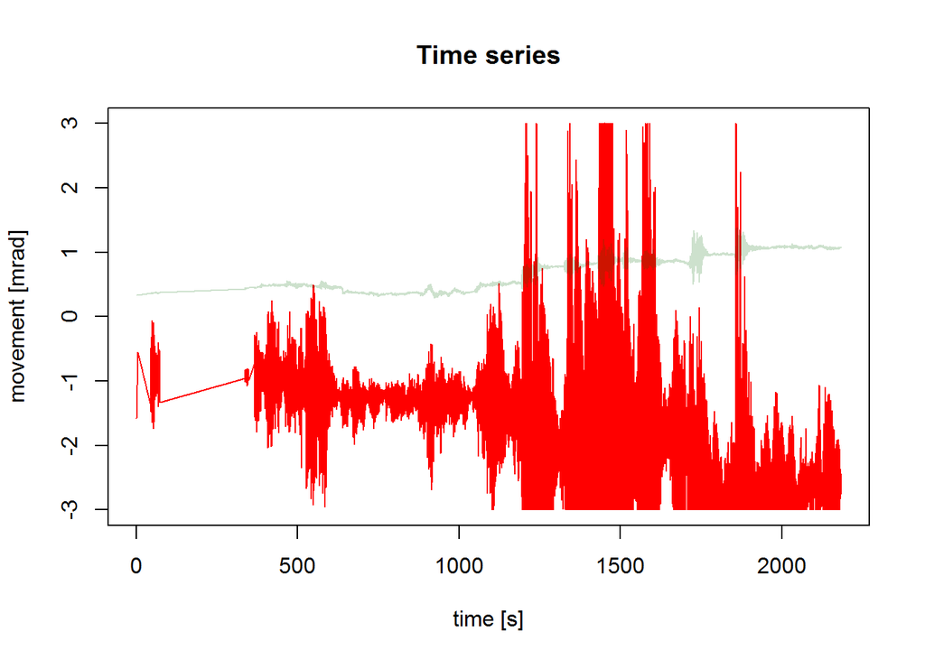

```r
plot(Data$Epoch,Data$across,type='l',col = 'red', main = "Time series",xlab = "time [s]", ylab = "movement [mrad]")
lines(Data$Epoch,Data$along,col = rgb(00,100,0,50, maxColorValue = 255))
```

# Future work

Good luck. Feel free to use any software package you fell comftable with. Data is small enough to be processed in Excel, though more advanced packages would be recommended.

### Some suggestions on future work

- Sync data using known time segments
- Can we see a drift in XY data? This would suggest poor mounting.
- (optional) Can you use first column to estimate sub-second value? Check commits from 2016 for existing code working on it and use *ExtractNivel.bat* to parser Nivel data instead.

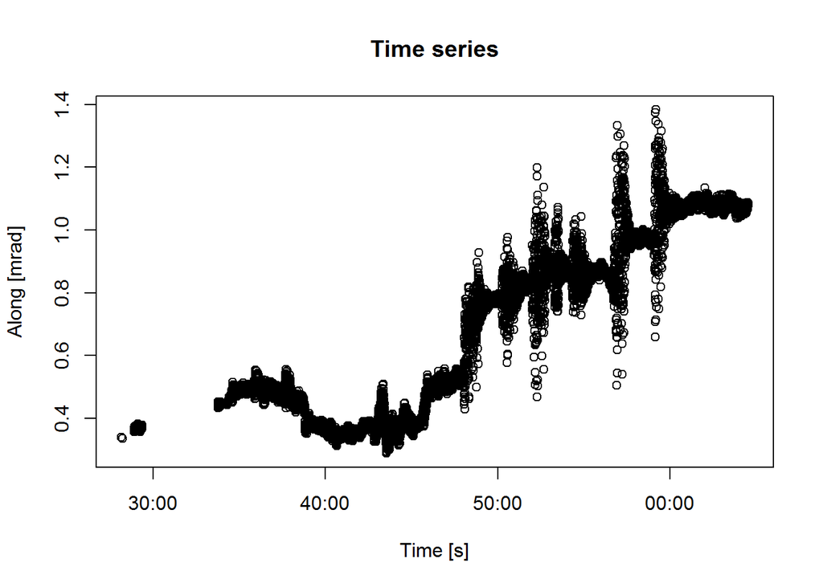

```r
plot(Data$Time,Data$along, main = "Time series",xlab = "Time [s]", ylab = "Along [mrad]")
```

```r
#dev.copy(png,file = "plot1_time.png",width = 980, height = 980, units = "px", pointsize = 25)
#dev.off() #close device
```